# DA5030 Regression

Assignment 07.1 : Multiple Linear Regression

Larkin, Yvonne

Fall, 2025 ; October 28, 2025

## 1. Create Project

Objective : use a multiple linear regression model to predict CPU performance using [cpu_data.csv](https://s3.us-east-2.amazonaws.com/artificium.us/datasets/cpu-data.csv) data file.

```r
library("psych") # pairs.plot
library("caret") # createDataPartition
library("ggplot2") # ggplot
library("e1071") # naiveBayes
```

## 2. Inspect Data

### 2.1 Load Data to `df`

Visual inspection of the file show there are no headers, no string values, and delimited by commas.

```r
url <- "https://s3.us-east-2.amazonaws.com/artificium.us/datasets/cpu-data.csv"
df <- read.csv(url,
               header = F)

#name columns by feature
colnames(df) <- c("MYCT", "MbMIN", "MMAX", "CACH", "CHMIN", "CHMAX", "PRP")

#confirm load
head(df, 10)
```

|  | MYCT | MbMIN | MMAX | CACH | CHMIN | CHMAX | PRP |
| --- | --- | --- | --- | --- | --- | --- | --- |
| 1 | 125 | 256 | 6000 | 256 | 16 | 128 | 198 |
| 2 | 29 | 8000 | 32000 | 32 | 8 | 32 | 269 |
| 3 | 29 | 8000 | 32000 | 32 | 8 | 32 | 220 |
| 4 | 29 | 8000 | 32000 | 32 | 8 | 32 | 172 |
| 5 | 29 | 8000 | 16000 | 32 | 8 | 16 | 132 |
| 6 | 26 | 8000 | 32000 | 64 | 8 | 32 | 318 |
| 7 | 23 | 16000 | 32000 | 64 | 16 | 32 | 367 |
| 8 | 23 | 16000 | 32000 | 64 | 16 | 32 | 489 |
| 9 | 23 | 16000 | 64000 | 64 | 16 | 32 | 636 |
| 10 | 23 | 32000 | 64000 | 128 | 32 | 64 | 1144 |

### 2.2 Basic `df` inspection

```r
str(df)
```

```
## 'data.frame':    209 obs. of  7 variables:
##  $ MYCT : int  125 29 29 29 29 26 23 23 23 23 ...
##  $ MbMIN: int  256 8000 8000 8000 8000 8000 16000 16000 16000 32000 ...
##  $ MMAX : int  6000 32000 32000 32000 16000 32000 32000 32000 64000 64000 ...
##  $ CACH : int  256 32 32 32 32 64 64 64 64 128 ...
##  $ CHMIN: int  16 8 8 8 8 8 16 16 16 32 ...
##  $ CHMAX: int  128 32 32 32 16 32 32 32 32 64 ...
##  $ PRP  : int  198 269 220 172 132 318 367 489 636 1144 ...
```

```r
summary(df)
```

```
##       MYCT            MbMIN            MMAX            CACH
##  Min.   :  17.0   Min.   :   64   Min.   :   64   Min.   :  0.00
##  1st Qu.:  50.0   1st Qu.:  768   1st Qu.: 4000   1st Qu.:  0.00
##  Median : 110.0   Median : 2000   Median : 8000   Median :  8.00
##  Mean   : 203.8   Mean   : 2868   Mean   :11796   Mean   : 25.21
##  3rd Qu.: 225.0   3rd Qu.: 4000   3rd Qu.:16000   3rd Qu.: 32.00
##  Max.   :1500.0   Max.   :32000   Max.   :64000   Max.   :256.00
##
##      CHMIN            CHMAX             PRP
##  Min.   : 0.000   Min.   :  0.00   Min.   :   6.0
##  1st Qu.: 1.000   1st Qu.:  5.00   1st Qu.:  27.0
##  Median : 2.000   Median :  8.00   Median :  50.0
##  Mean   : 4.609   Mean   : 18.27   Mean   : 105.6
##  3rd Qu.: 6.000   3rd Qu.: 24.00   3rd Qu.: 113.0
##  Max.   :52.000   Max.   :176.00   Max.   :1150.0
##  NA's   :2
```

```r
unique_value_counts <- sapply(df, function(x){length(unique(x))})
unique_value_counts
```

```
##  MYCT MbMIN  MMAX  CACH CHMIN CHMAX   PRP
##    60    25    23    22    16    31   116
```

#### Information Provided

We are told the data file contains these columns expressing the following CPU characteristics:

- MYCT: machine cycle time in nanoseconds (integer)
- MbMIN: minimum main memory in kilobytes (integer)
- MMAX: maximum main memory in kilobytes (integer)
- CACH: cache memory in kilobytes (integer)
- CHMIN: minimum channels in units (integer)
- CHMAX: maximum channels in units (integer)
- **PRP**: published relative performance (integer) **(target variable)**

Upon loading the data file to `df` we can see there are 7 columns where the above feature names were assigned as corresponding headers, all columns are in fact `integer` class typre, and there are 209 observations. From the `str( )` `head( )` and `summary( )` the values of each column appear to be discrete categories with numeric magnitude that is relevant, and the count of how many unique values are present for each feature does indicate discrete and somewhat limited categories

Looking at outputs, the ‘Mean’ is roughly $2\times$ larger than the ‘Median’ with a `range` of all ‘positive’ values. This typically indicates a *‘non-normal’ distribution* (either that or it has extreme values). But the glimpse of values observed in the data from these features seem to have a *multiplicative of 4* distinction *to me* so the distribution is unknown immediately and visualization of the data would help determine distribution and any relationship. Especially if this is taken into consideration when looking at the ‘Mean’ values that are relatively in the middle of ‘1st Qu.’ and ’3rd Qu.’values. Lastly, there are **2 ‘NA’** values in the feature **‘CHMIN’**.

### 2.3 Visualization of `df` Features

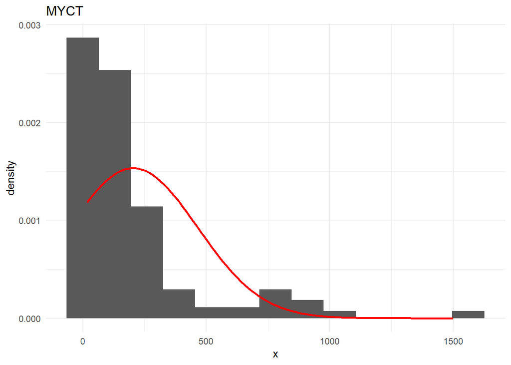

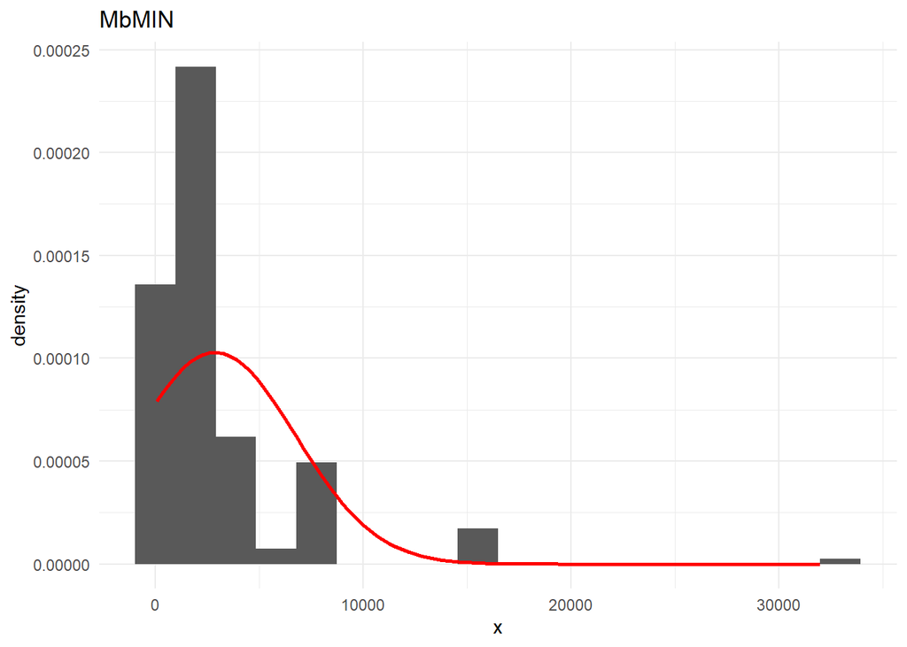

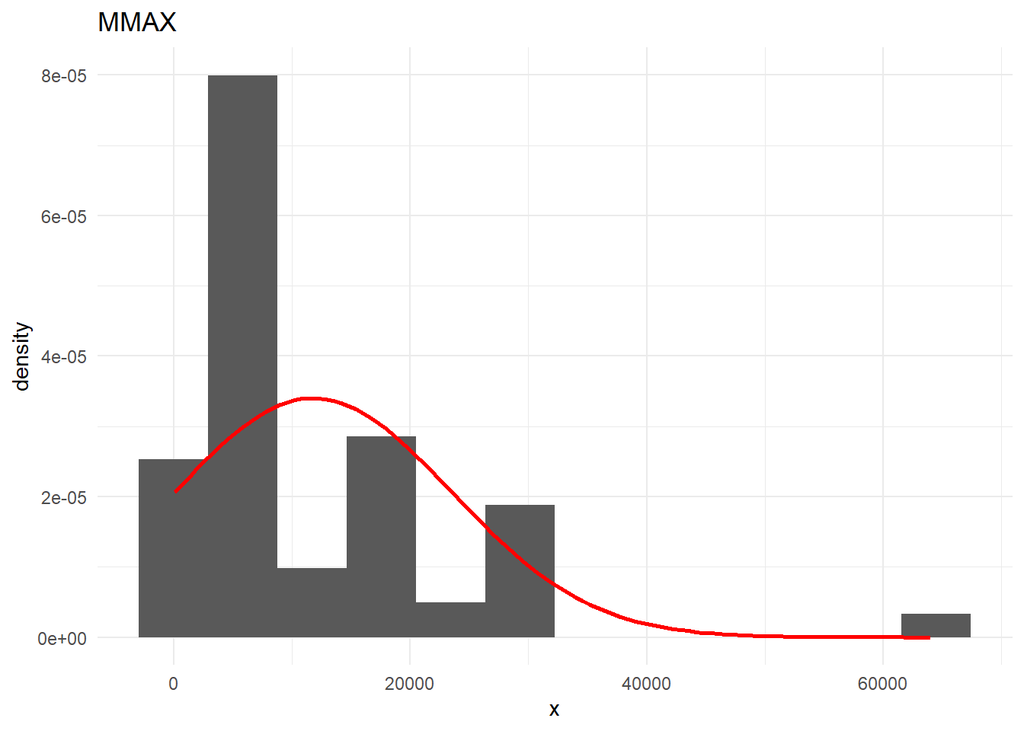

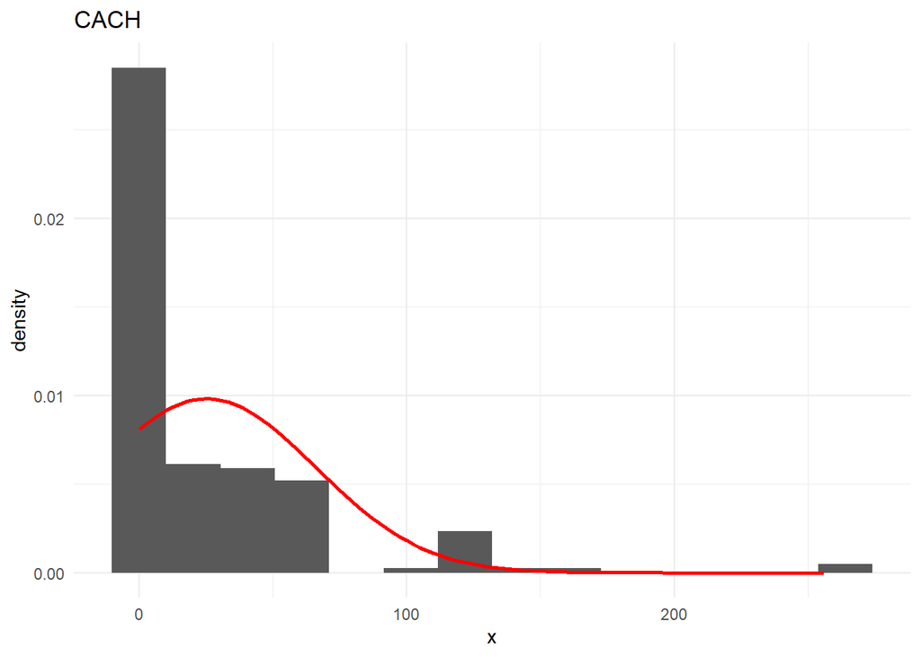

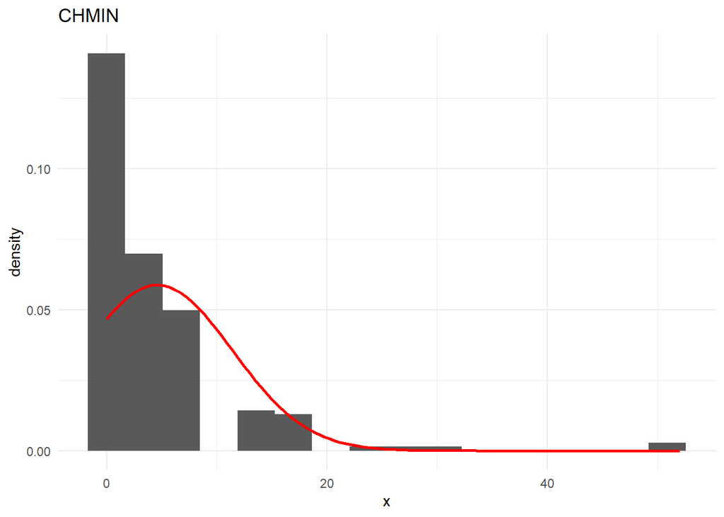

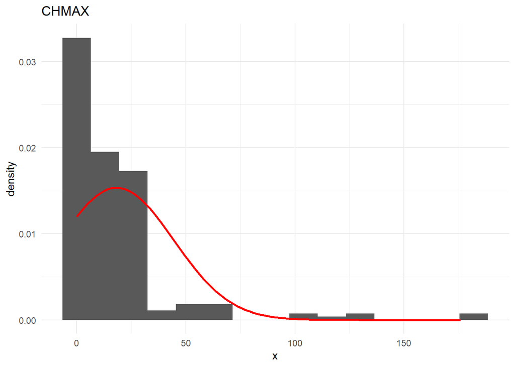

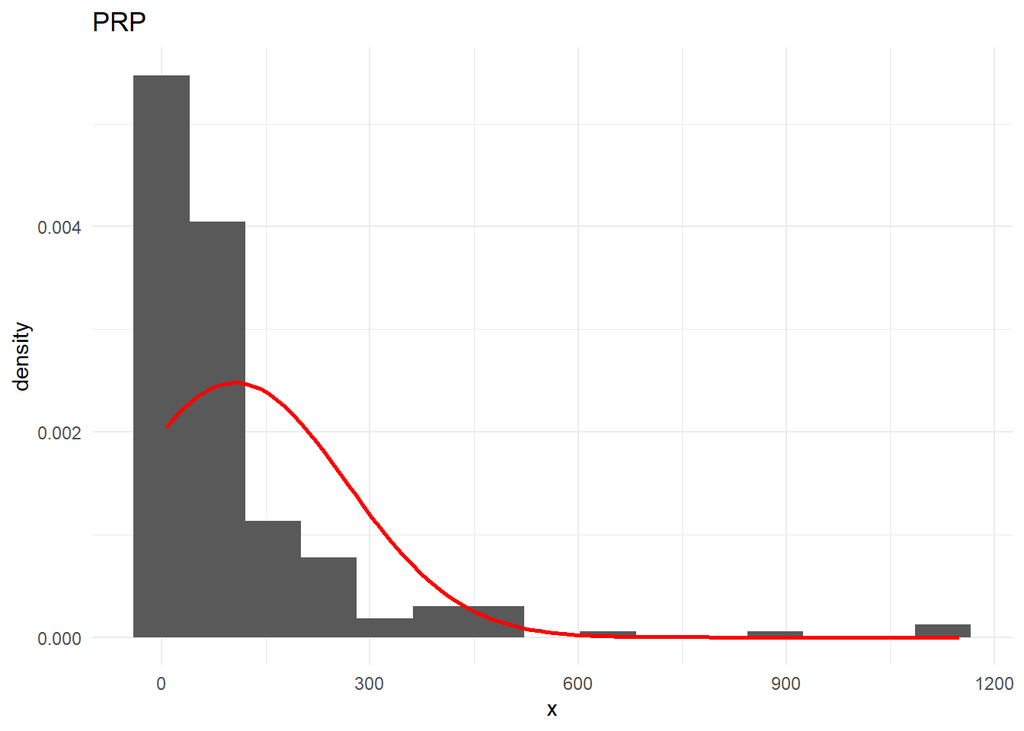

```r
# logic from Decision Tree
for (i in 1:ncol(df)) {
  # data column
  num_feat <- df[[i]]
  # numeric plotting with ggplot2 T.T
  np <- ggplot(data.frame(x = num_feat),
              aes(x)) +
    # set bin width to half the sd value of the feature so it is easier to visualize empirical rule
    geom_histogram(aes(y = ..density..),
                   binwidth = sd(num_feat, na.rm = T)/2) +
    stat_function(fun = dnorm,
                  args = list(mean = mean(num_feat, na.rm = T), sd = sd(num_feat, na.rm = T)),
                  color = "red",
                  size = 1) +
    ggtitle(colnames(df)[i]) +
    theme_minimal()

  print(np)
}
```

### 2.4 Shapiro-Wilks Test for Normality

```r
#initialize list
norm.list <- vector("list", length = ncol(df))

for(c in 1:ncol(df)){
  norm.list[[c]] <- temp <- shapiro.test(df[,c])
  print(paste0("Column '", names(df)[c], "' has a W statistic = ", round(temp$statistic, 3), " and p-value = ", formatC(temp$p.value, digits = 3, format = 'fg')))
}
```

```
## [1] "Column 'MYCT' has a W statistic = 0.663 and p-value = 0.0000000000000000000376"
## [1] "Column 'MbMIN' has a W statistic = 0.612 and p-value = 0.00000000000000000000171"
## [1] "Column 'MMAX' has a W statistic = 0.758 and p-value = 0.0000000000000000308"
## [1] "Column 'CACH' has a W statistic = 0.646 and p-value = 0.0000000000000000000125"
## [1] "Column 'CHMIN' has a W statistic = 0.566 and p-value = 0.000000000000000000000182"
## [1] "Column 'CHMAX' has a W statistic = 0.597 and p-value = 0.000000000000000000000753"
## [1] "Column 'PRP' has a W statistic = 0.558 and p-value = 0.000000000000000000000095"
```

Based on the Shapiro-Wilks Test for normality where a W statistic closer to 1 indicates a distribution reflective of *normal distribution* a p-value < 0.05 means that the ‘null hypothesis’ for a normal distribution is rejected. Because most “W” statistics are closer to 0.5 than 1.0 and the p-values are significantly below 0.05, the null is rejected for normality. This means transformations will be needed to make a multiple-linear regression model.

### 2.5 Correlation Benchmark for Untransformed Data

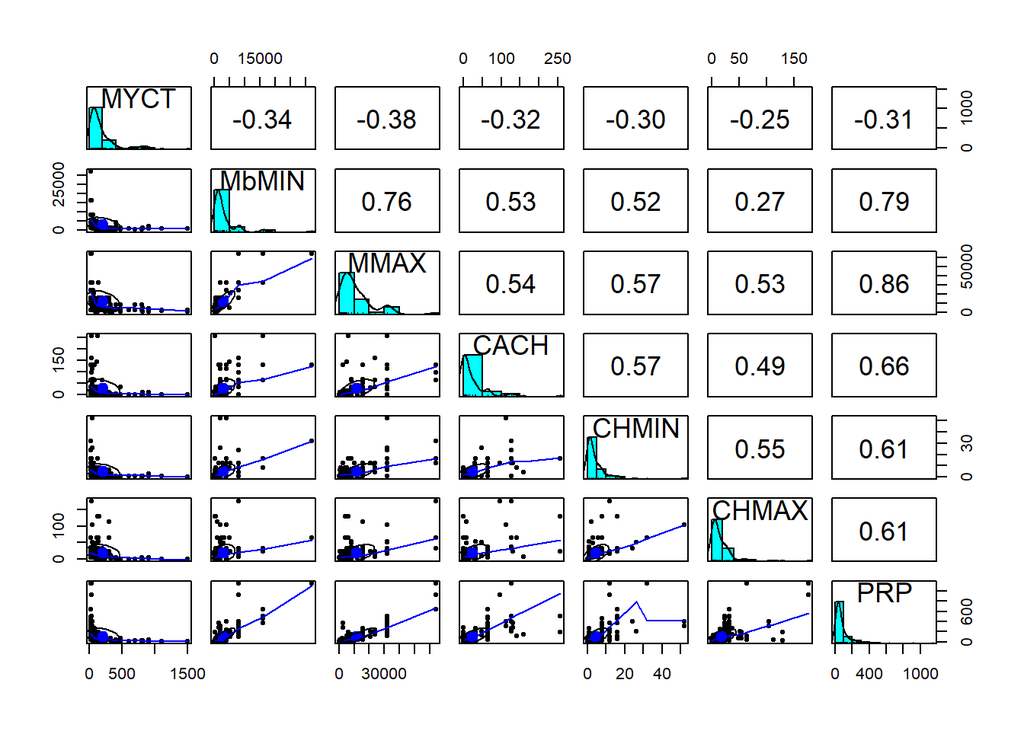

```r
pairs.panels(df)
```

## Relevant Domain Knowledge

Because I have limited domain knowledge with CPU components etc, I did some investigation on the features presented in order to appropriately handle Missing Values and Outliers.I believe some information about the units of measure for digital data should be noted, especially that conversions of digital data have constant relationships and a ‘bit’ is the smallest unit of data that can only be represented by a 0 or 1 [^1].

##### MbMAX, MMAX, CACH

Base measures:

Digital Data Conversions where kilbytes is indicated as the unit for memory associated columns:

- 1 kB [^3] = 0.001 MB = 1024 Bytes = 8192 bits
- 1 MB = 1,000 kB
- 1 ns = 0.000000001 s = $1\times10^{-9}$s

##### PRP*, CHMIN, CHMAX, MYCT:

- CPU [^4] = central processing unit
- PRP is relative performance and target but : Computer performance[^5] is the amount of useful work accomplished by a computer system
- CHMIN & CHMAX : Channels [^6] have their capacity as additive over independent channels
- MYCT : Cycle Time [^7] is how long it takes to process a given job

## 3. Missing Values

```r
#initialize object as false for print
found <- F

for(c in 1:ncol(df)){
  missing.Values <- which(is.na(df[,c]))
  num.Missing.Values <- length(missing.Values)
  if(num.Missing.Values > 0){
    print(paste0("Column '", names(df)[c], "' has ", num.Missing.Values, " missing values"))
    found <- T
  }
}
```

```
## [1] "Column 'CHMIN' has 2 missing values"
```

With only 2 `NA` values in the entire data set and within the same column, it seems the values are ‘Missing Completely at Random’ and should be imputed. The method of feature average was discouraged, so I think the exploration of kNN, kNN regression, Model Regression Tree, Decision Tree, and Naive Bayes are the potential options for imputation.

kNN and Decision Tree are non-parametric, while Naive Bayes is reasonably parametric but has amplified combined predictive effect for categories. I explored all of these methods except the binned Decision Tree. I will mainly explain my choice with limited code on the rejected methods.

The features are integers, meaning they are numeric in value but they can be ‘binned’ into discrete categories easily.

#### Continuous Regression (not selected)

I did attempt numeric *regression* where a continuous variable was returned by either *kNN Regression* or *Model Regression Tree* where various ‘k’ and ‘cp’ values were explored respectively. Overall, accuracy was roughly 50% where despite a high `cor( )` value of approximately 0.88; but there are many ‘bins’ and the numeric magnitude of the feature does have importance for impact on pairing with other features. Because of dense clustering of lower magnitude values the continuous variable return had large error/high variance even attempting to select the closest ‘discrete category’. If scaling was not performed first , which is unusual for kNN, the predictions were basically the same as the scaled.

#### Discrete Classification (Naive Bayes Selected)

Again, just scaling features to utilize the non-parametric methods of kNN or Decision Tree had a rough accuracy of 50% with low ‘kappa’. Due to this and the relatively low correlation found before any transformations, it made the idea of transforming to a relatively normal distribution and utilizing the amplified prediction power of Naive Bayes for low impact features a better approach. After visual inspection of all model predictions and validation sets, Naive Bayes seemed the more accurate even if the ‘accuracy’ percents were similar. That has to do with the *naive* nature of the mode, but therefore the method *I selected Naive Bayes Classification for imputation of missing values.*

### 3. Imputation by Naive Bayes Classification

Naive Bayes assumptions:

- relatively normal distribution
- independent variables (not necessarily true but currently low correlation)
- equal importance of variables (so even small impact will contribute to classification)
- works best for categorical data (so need to ‘re-categorize’ after transformation)

General handling for Data Models:

I will treat the numeric values as *ordinal features* with *ranked order* based on the *min-max* scaled value.  
Since **PRP** is the overall goal and the relation is not defined, and overfitting should be avoided; *the column ‘PRP’ with be excluded for the model predictions for ‘CHMIN’.* **The `NA` values (rows : 31 , 170** are the ultimate goal so they will also be removed from the training and testing sets.

```r
# data frames for missing value imputation
targets <- which(is.na(df$CHMIN))
# remove PRP for CHMIN imputation
df.nb <- df[, -which(colnames(df) == 'PRP')]
```

### 3.1 Normalize the Data for Naive Bayes

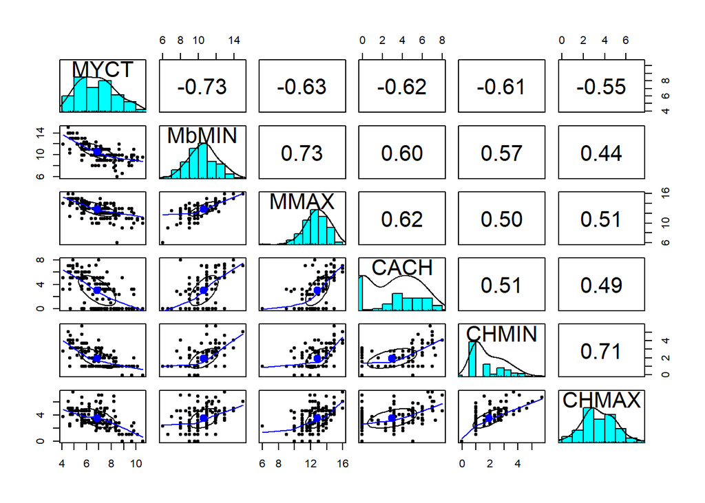

```r
#initialize data frame for log_2 transformation
df.log2 <- df.nb
# log(1, base = 2) = 0
for(col in 1:ncol(df.log2)) {
  min_val <- min(df.nb[[col]], na.rm = TRUE)
  if (min_val <= 0) {
    shift <- abs(min_val) + 0.99
    df.log2[[col]] <- log(df.nb[[col]] + shift, base = 2)
  } else {
    df.log2[[col]] <- log(df.nb[[col]], base = 2)
  }
}

pairs.panels(df.log2)
```

### 3.2 Scale Up and Factor for Naive Bayes Categorical Use

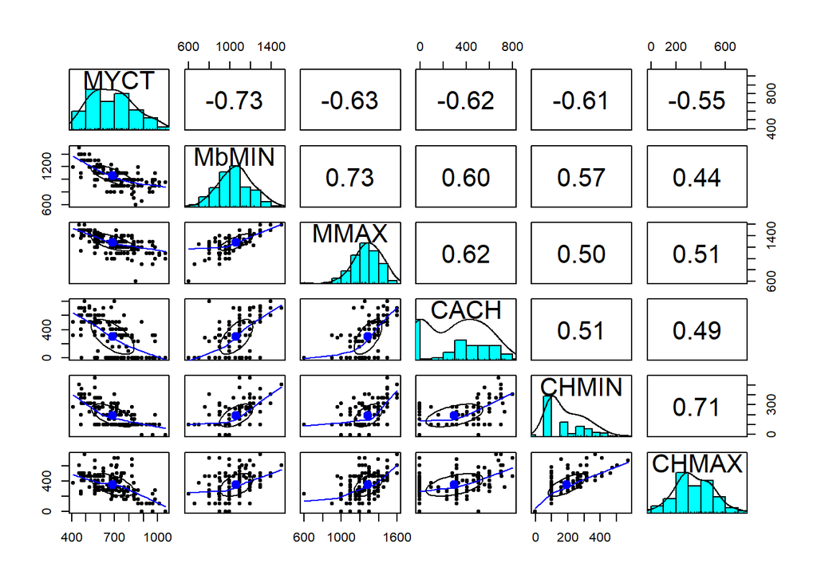

```r
# transformations for use as factors
df.nb <- as.data.frame(lapply(df.log2, round, digit = 3))
df.nb.scale <- 100 * df.nb

# categorical data.frame for nb.model
df.nbf <- as.data.frame(lapply(df.nb.scale, as.factor))

# maintains some shape when scaled
pairs.panels(df.nb.scale)
```

### 3.3 Lookup Factor Values in Data Frame

With the creation of data.frame copies to manipulated for each transformation of the data, a 1:1 index of values can be used for look up to impute predicted value.

```r
# CHMIN target
chminF <- data.frame(Label = df$CHMIN,
                     Log2 = df.log2$CHMIN,
                     Decimal = df.nb$CHMIN,
                     Scaled = df.nb.scale$CHMIN,
                     Factor = df.nbf$CHMIN)
chminF2 <- as.data.frame(lapply(chminF, function(x){sort(unique(x))}))
table.lookup <- knitr::kable(chminF2, caption = "'CHMIN' Look-up Key")
```

‘CHMIN’ Look-up Key

| Label | Log2 | Decimal | Scaled | Factor |
| --- | --- | --- | --- | --- |
| 0 | -0.0144996 | -0.014 | -1.4 | -1.4 |
| 1 | 0.9927684 | 0.993 | 99.3 | 99.3 |
| 2 | 1.5801455 | 1.580 | 158.0 | 158 |
| 3 | 1.9963887 | 1.996 | 199.6 | 199.6 |
| 4 | 2.3190398 | 2.319 | 231.9 | 231.9 |
| 5 | 2.5825560 | 2.583 | 258.3 | 258.3 |
| 6 | 2.8052925 | 2.805 | 280.5 | 280.5 |
| 7 | 2.9981955 | 2.998 | 299.8 | 299.8 |
| 8 | 3.1683211 | 3.168 | 316.8 | 316.8 |
| 12 | 3.6993295 | 3.699 | 369.9 | 369.9 |
| 16 | 4.0866139 | 4.087 | 408.7 | 408.7 |
| 24 | 4.6432790 | 4.643 | 464.3 | 464.3 |
| 26 | 4.7543531 | 4.754 | 475.4 | 475.4 |
| 32 | 5.0439569 | 5.044 | 504.4 | 504.4 |
| 52 | 5.7276482 | 5.728 | 572.8 | 572.8 |

### 3.4 Test *Transformed and Scaled* Data’s Normality to satisfy Naive Bayes Assumption

```r
#initialize list
norm.list.scale <- vector("list", length = ncol(df.nb.scale))

for(c in 1:ncol(df.log2)){
  norm.list.scale[[c]] <- temp <- shapiro.test(df.nb.scale[,c])
  print(paste0("Column '", names(df.nb.scale)[c], "' has a W statistic = ", round(temp$statistic, 3), " and p-value = ", formatC(temp$p.value, digits = 3, format = 'fg')))
}
```

```
## [1] "Column 'MYCT' has a W statistic = 0.967 and p-value = 0.000086"
## [1] "Column 'MbMIN' has a W statistic = 0.973 and p-value = 0.000533"
## [1] "Column 'MMAX' has a W statistic = 0.958 and p-value = 0.00000701"
## [1] "Column 'CACH' has a W statistic = 0.881 and p-value = 0.00000000000942"
## [1] "Column 'CHMIN' has a W statistic = 0.864 and p-value = 0.00000000000121"
## [1] "Column 'CHMAX' has a W statistic = 0.982 and p-value = 0.00997"
```

Here we can see that the data after transformation is significantly closer to a normal distribution (maintained in scaled data) based on the Shapiro-Wilk’s W statistic being very close to 1. While the p-value is below 0.05 to reject the null hypothesis of normal distribution this is significantly closer. So proceeding with Naive Bayes to impute the missing value is good. Also these methods will be used to transform. the multiple linear regression model.

I will note I spent way longer than I should have to realize the $x =2^{y}$ distribution and ended up testing gamma, exponential, natural log, and did so with caret and e107. I tried cross validations, Box-Cox (my backup), I did `sqrt()` into `log()` base e (my very first approach - so at least intuitively I was kinda there), PCA, and then realized log base 2. I finally realized the log should have base 2 because I remember Professor Schedlbauer’s Lecture [The C5.0 Algorith,](https://vimeo.com/835739979) where he comments that *‘in computer science we always use base two’*. But I got there eventually.

### 3.5 Split the Data for Naive Bayes Model Testing

Intentionally left warning here, to highlight that some values aren’t present in data sets.

```r
# reproducible results
set.seed(16)
#remove NA targets
df.nbf2 <- df.nbf[-targets,]

#index for training and validation
split.index <- createDataPartition(df.nbf2$CHMIN,
                                   p = 0.8,
                                   list = FALSE)
```

```
## Warning in createDataPartition(df.nbf2$CHMIN, p = 0.8, list = FALSE): Some
## classes have a single record ( 299.8, 464.3, 475.4, 504.4 ) and these will be
## selected for the sample
```

```r
# testing (t) and validation (v) sets
nb.t <- df.nbf2[split.index,]
nb.v <- df.nbf2[-split.index,]

# labels for t & v sets
factor.t <- df.nbf2[split.index, 'CHMIN']
factor.v <- df.nbf2[-split.index, 'CHMIN']
```

### 3.6 Build Naive Bayes Model and Evaluate Accuracy

```r
nb.model <- naiveBayes(CHMIN ~.,
                       data = nb.t,
                       laplace = 0.000001)

nb.prediction <- predict(nb.model,
                         newdata = nb.v[,-which(colnames(nb.v) == 'CHMIN')])

#accuracy
cM_nb.model <- confusionMatrix(nb.prediction, factor.v)
cM_nb.model$overall['Accuracy']
```

```
##  Accuracy
## 0.6944444
```

```r
cM_nb.model$overall['Kappa']
```

```
##     Kappa
## 0.5690968
```

This is actually a really decent model (especially considering all other models were returning an accuracy near 50% with a Kappa near 0.25 for most of my previous attempts). I will use this to predict the missing ‘CHMIN’ values and look up the prediction’s corresponding labels to impute.

### 3.5 Predict Missing ‘CHMIN’ Values

```r
# object previously saved df.targets
#transform new data
df.new <- df.nbf[targets,]

pred.NA <- predict(nb.model,
                   newdata = df.new)
```

## 4. Use Look-up of Prediction Values to Impute: 12 & 16

```r
# apply look up value to NA
df[targets, 'CHMIN'] <- NA.labels <- chminF2[which(chminF2$Factor %in% pred.NA), 'Label']
df[targets, ]
```

|  | MYCT | MbMIN | MMAX | CACH | CHMIN | CHMAX | PRP |
| --- | --- | --- | --- | --- | --- | --- | --- |
| 31 | 25 | 1310 | 2620 | 131 | 12 | 24 | 274 |
| 170 | 38 | 4000 | 16000 | 128 | 16 | 32 | 212 |

The Naive Bayes Model predicted the ‘CHMIN’ for the target observations: *row =31 , 170 Imputed Value = 12 , 16*. Looking at the observation values, the imputed values do make sense for the corresponding ‘CHMAX’ which we say a strong correlation between previously.

## 5. Handling Outliers

Again a majority of these values are actually categorical in nature where magnitude increases make sense. So Rather the values should be evaluated with that in mind and the columns described units of measure previously discussed. So normalization of the data should be done first, since outliers are evaluations of empirical distribution norms. Which is by a `log_2` transformation method identified previously.

Unlike the previous scaling though, ‘0.01’ instead of ‘0.99’ will be used for any zeros in the data set to avoid ‘-Inf’ return but maintain 0 as a distinct value and not part of values transformed that were 1.

### 5.1 Normalize all Data for Outlier Evaluation

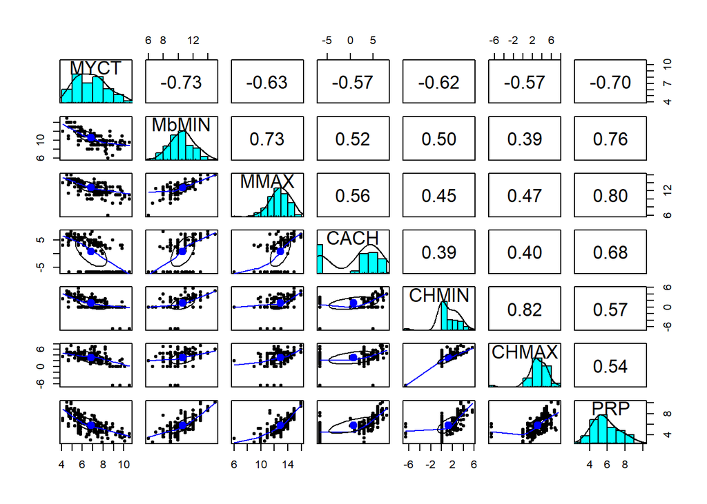

```r
# df of All transformed data
dfA.log2 <- df
# log(1, base = 2) = 0
for(col in 1:ncol(dfA.log2)) {
  min_val <- min(df[[col]], na.rm = TRUE)
  if (min_val <= 0) {
    shift <- abs(min_val) + 0.01
    dfA.log2[[col]] <- log(df[[col]] + shift, base = 2)
  } else {
    dfA.log2[[col]] <- log(df[[col]], base = 2)
  }
}

pairs.panels(dfA.log2)
```

### 5.2 Identify Outliers by *z-Score*

Borrow logic and printing from [Module 07.5](http://artificium.us/lessons/03.ml/l-3-440-primer-regression/l-3-440.html) by Professor Schedlbauer.

```r
#create z-score matrix of transformed values
df.z <- as.data.frame(lapply(dfA.log2, scale))
# loop print
for (c in 1:ncol(df.z)) {
  # outliers
  outliers <- which(abs(df.z[,c]) > 3.0)
  #print statements
  if (length(outliers) > 0) {
    ## found outliers; replace with NA and impute later
    cat("Found ", length(outliers), " outliers in column '", names(df)[c], "': \n")
    cat("   --> ", df[outliers,c], "\n")
  }
}
```

```
## Found  1  outliers in column ' MMAX ':
##    -->  64
## Found  5  outliers in column ' CHMIN ':
##    -->  0 0 0 0 0
## Found  5  outliers in column ' CHMAX ':
##    -->  0 0 0 0 0
```

### 5.3 Treat Channel Outliers : no change

Again this requires some domain knowledge, I am not 100% positive but I believe “0” channels is possible and therefore I will leave it alone. Due to some online searching and the Wikipedia quote :  
|“Much later, the channels were implemented as an on-board processor residing in the same box as the CPU, |generally referred to as a”channel processor”, and which was usually a RISC processor, but which could |be a System/390 microprocessor with special microcode as in IBM’s CMOS mainframes.”[^8]

### 5.4 ‘MMAX’ outliers and ‘MbMIN’ correlation

```r
# original data entry
mmax.out <- which(abs(df.z$MMAX) > 3.0)
df[mmax.out,]
```

|  | MYCT | MbMIN | MMAX | CACH | CHMIN | CHMAX | PRP |
| --- | --- | --- | --- | --- | --- | --- | --- |
| 15 | 350 | 64 | 64 | 0 | 1 | 4 | 10 |

```r
# corresponding z-Score values
round(df.z[mmax.out,], 2)
```

|  | MYCT | MbMIN | MMAX | CACH | CHMIN | CHMAX | PRP |
| --- | --- | --- | --- | --- | --- | --- | --- |
| 15 | 1.07 | -2.9 | -4.61 | -1.37 | -0.63 | -0.5 | -1.65 |

The ‘MMAX’ outlier definitely appears to be an outlier, but ‘MbMIN’ makes me question the z-Score cut off for the Memory associated features.

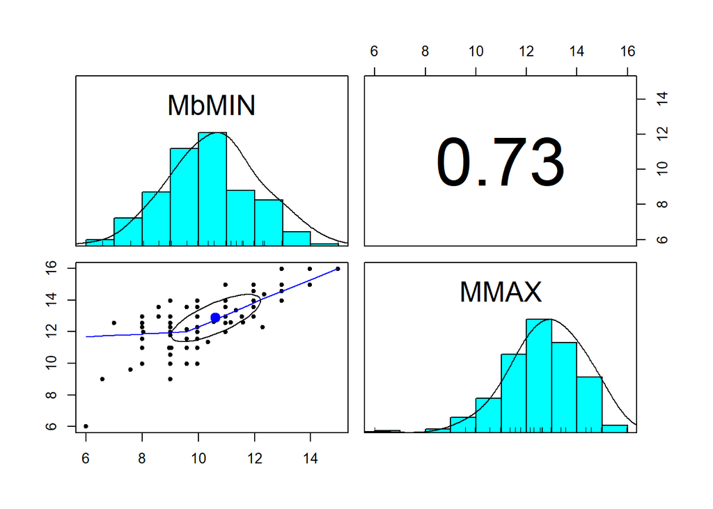

```r
pairs.panels(dfA.log2[,c('MbMIN', 'MMAX')])
```

### 5.5 Manual Update to ‘MMAX’ Outlier to 64000

```r
df[mmax.out, 'MMAX'] <- as.integer(64000)
df[mmax.out,]
```

|  | MYCT | MbMIN | MMAX | CACH | CHMIN | CHMAX | PRP |
| --- | --- | --- | --- | --- | --- | --- | --- |
| 15 | 350 | 64 | 64000 | 0 | 1 | 4 | 10 |

I do believe the ‘MMAX’ is incorrect and will impute the value 64000 to reflect a MB to kB conversion by multiplying the outlier by 1000.

### 5.6 ‘MbMIN’ lower z-Score to 2.9

I only changed the cut-off value for MbMIN, I did look at other column z-Score values but felt the other features were fine as is.

```r
mbmin.out <- which(abs(df.z$MbMIN) > 2.9)
df[mbmin.out,]
```

|  | MYCT | MbMIN | MMAX | CACH | CHMIN | CHMAX | PRP |
| --- | --- | --- | --- | --- | --- | --- | --- |
| 15 | 350 | 64 | 64000 | 0 | 1 | 4 | 10 |

```r
# replace as NA
dfA.log2[mbmin.out, 'MbMIN'] <- NA
```

### 5.7 Calculated ‘MbMIN’ Value From ‘MMAX’

```r
# integer vector of Multipliers
multiplier <- as.integer(df[-mbmin.out, 'MMAX'] / df[-mbmin.out, 'MbMIN'])
avg.mult <- mean(multiplier)
# vector of unique multipliers
mode.mult <- sort(unique(multiplier))
# initialize the count vector for multipliers found
count.mode <- vector(length = length(mode.mult))
# tally counts
for(i in 1:length(count.mode)){
  count.mode[i] <- length(which(multiplier == mode.mult[i]))
}
# data.frame of counts to multiplier
mode.df <- data.frame(count = count.mode,
                      multiplier = mode.mult)
# find maximum count of multiplier used
mode.index <- which(mode.df$count == max(mode.df$count))
mode.found <- mode.df[mode.index,'multiplier']
mode.found
```

```
## [1] 4
```

#### Use Mode of Multiplicative Factor between ‘MbMIN’ & ‘MMAX’ = 4

After looking at the data, it appears that ‘MbMIN’ and ‘MMAX’ have a scaled relationship. I divided all other ‘MMAX’ by ‘MbMIN’ with result coerced to integer. Found the resultant mode multiplier. Then divided the outlier’s corresponding ‘MMAX’ by that multiplier to impute for the outlier in ‘MbMIN’

### 5.8 Impute MbMIN Value = 16000

```r
df[mbmin.out, 'MbMIN'] <- df[mbmin.out, 'MMAX']/mode.found
df[mbmin.out,]
```

|  | MYCT | MbMIN | MMAX | CACH | CHMIN | CHMAX | PRP |
| --- | --- | --- | --- | --- | --- | --- | --- |
| 15 | 350 | 16000 | 64000 | 0 | 1 | 4 | 10 |

After evaluating the ‘MbMIN’ column I did not have confidence to exclude *96* as an outlier by using a ‘2.5’ z-Score, so I only lowered the z-Score to ‘2.9’. Most observations do not have the ‘MbMIN’ == ‘MMAX’, by they do appear to be a factor relation, and the `pairs.panel( )` supports a strong correlation.

Therefore, I think treating the outlier for row 15 in ‘MbMIN’ should be treated as a missing value to impute.

## 6. Normalize `df` with $\log_2$ for Regression

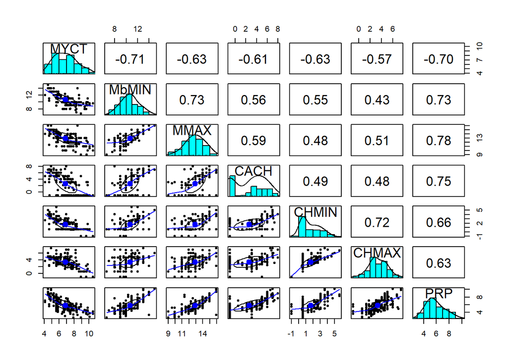

```r
df.norm <- df
# log(1, base = 2) = 0
for(col in 1:ncol(df.norm)) {
  min_val <- min(df.norm[[col]], na.rm = TRUE)
  if (min_val <= 0) {
    shift <- abs(min_val) + 0.5
    df.norm[[col]] <- log(df[[col]] + shift, base = 2)
  } else {
    df.norm[[col]] <- log(df[[col]], base = 2)
  }
}

pairs.panels(df.norm)
```

### 6.1 Confirm Normality again with Shapiro-Wilks Test

```r
#initialize list
norm.list.scale <- vector("list", length = ncol(df.norm))

for(c in 1:ncol(df.log2)){
  norm.list.scale[[c]] <- temp <- shapiro.test(df.norm[,c])
  print(paste0("Column '", names(df.nb.scale)[c], "' has a W statistic = ", round(temp$statistic, 3), " and p-value = ", formatC(temp$p.value, digits = 3, format = 'fg')))
}
```

```
## [1] "Column 'MYCT' has a W statistic = 0.967 and p-value = 0.000086"
## [1] "Column 'MbMIN' has a W statistic = 0.971 and p-value = 0.000246"
## [1] "Column 'MMAX' has a W statistic = 0.972 and p-value = 0.000398"
## [1] "Column 'CACH' has a W statistic = 0.868 and p-value = 0.0000000000016"
## [1] "Column 'CHMIN' has a W statistic = 0.879 and p-value = 0.00000000000704"
## [1] "Column 'CHMAX' has a W statistic = 0.98 and p-value = 0.00531"
```

## 7. Correlation Matrix

There have been multiple `pairs.panels( )` used so I will utilize `cor( )` for a fully filled Correlation Matrix.

```r
knitr::kable(round(cor(df.norm), 3), caption = "Transformed Data Correlation Matrix")
```

Transformed Data Correlation Matrix

|  | MYCT | MbMIN | MMAX | CACH | CHMIN | CHMAX | PRP |
| --- | --- | --- | --- | --- | --- | --- | --- |
| MYCT | 1.000 | -0.711 | -0.625 | -0.609 | -0.626 | -0.566 | -0.702 |
| MbMIN | -0.711 | 1.000 | 0.727 | 0.562 | 0.552 | 0.427 | 0.732 |
| MMAX | -0.625 | 0.727 | 1.000 | 0.592 | 0.476 | 0.511 | 0.776 |
| CACH | -0.609 | 0.562 | 0.592 | 1.000 | 0.495 | 0.478 | 0.750 |
| CHMIN | -0.626 | 0.552 | 0.476 | 0.495 | 1.000 | 0.719 | 0.662 |
| CHMAX | -0.566 | 0.427 | 0.511 | 0.478 | 0.719 | 1.000 | 0.632 |
| PRP | -0.702 | 0.732 | 0.776 | 0.750 | 0.662 | 0.632 | 1.000 |

Like previously stated there is a very strong correlation for multiple features. Based on the correlation Matrix, I would say all values that at 0.70 and above have a strong correlation.

### Multicollinearities between Predictor Features

1. CHMIN to CHMAX
2. MbMIN to MMAX
3. MYCT to MbMIN

### Features with a strong Correlation to PRP target:

1. MYCT (negative)
2. MbMIN
3. MMAX
4. CACH

It makes since for *min* and *max* of the same feature to have a strong correlation because directly impact what value the other one can have(i.e. minimum can’t exceed the maximum). Just like the relationship between cycle time and available memory makes sense

I personally believe removing the minimum values would make the most sense to avoid multimillionaires in the data, since the *maximum* Channels or Memory possible would limit the CPU’s overall performance as a *ceiling threshold* basically the computer is unable to exceed a certain level of performance.

I would choose to explore multiple iteration where I’d starting with removing ‘MbMIN’ and ‘CHMIN’ but with the use of all features into step-wise backward regression by p-value and `step()` for AIC you will see that those are actually both left in the model, but the resultant model has multicollinearity as a result (which is bad because it leads to overfitting).

## 8. Training (85%) and Validation (15%)

```r
# because of rounding , use 0.84 for split
split.index <- createDataPartition(df.norm$PRP,
                                   p = 0.84,
                                   list = FALSE)
reg.t <- df.norm[split.index, ]
reg.v <- df.norm[-split.index, ]
```

## 9. Multiple Linear Regressions

### 9.1 All Features

```r
# train model
reg.fit1 <- lm(PRP ~ MYCT + MbMIN + MMAX + CACH + CHMIN + CHMAX,
                data = reg.t)
summary(reg.fit1)
```

```
##
## Call:
## lm(formula = PRP ~ MYCT + MbMIN + MMAX + CACH + CHMIN + CHMAX,
##     data = reg.t)
##
## Residuals:
##     Min      1Q  Median      3Q     Max
## -3.3853 -0.4262  0.0152  0.4453  1.7520
##
## Coefficients:
##             Estimate Std. Error t value Pr(>|t|)
## (Intercept) -2.12627    0.96237  -2.209  0.02847 *
## MYCT         0.01170    0.05808   0.201  0.84060
## MbMIN        0.18745    0.05613   3.339  0.00103 **
## MMAX         0.36987    0.05826   6.349 1.88e-09 ***
## CACH         0.14984    0.02432   6.161 5.02e-09 ***
## CHMIN        0.16760    0.06350   2.639  0.00908 **
## CHMAX        0.12132    0.04899   2.476  0.01424 *
## ---
## Signif. codes:  0 '***' 0.001 '**' 0.01 '*' 0.05 '.' 0.1 ' ' 1
##
## Residual standard error: 0.6855 on 171 degrees of freedom
## Multiple R-squared:  0.8099, Adjusted R-squared:  0.8032
## F-statistic: 121.4 on 6 and 171 DF,  p-value: < 2.2e-16
```

### 9.2 Stepwise Backward-Elimination

#### 9.2.1 Remove MYCT

```r
reg.fit2 <- lm(formula = PRP ~ MbMIN + MMAX + CACH + CHMIN + CHMAX,
               data = reg.t)
summary(reg.fit2)
```

```
##
## Call:
## lm(formula = PRP ~ MbMIN + MMAX + CACH + CHMIN + CHMAX, data = reg.t)
##
## Residuals:
##     Min      1Q  Median      3Q     Max
## -3.3546 -0.4357  0.0100  0.4417  1.7541
##
## Coefficients:
##             Estimate Std. Error t value Pr(>|t|)
## (Intercept) -1.96984    0.56677  -3.476 0.000645 ***
## MbMIN        0.18314    0.05175   3.539 0.000517 ***
## MMAX         0.36836    0.05761   6.394 1.47e-09 ***
## CACH         0.14907    0.02395   6.224 3.59e-09 ***
## CHMIN        0.16538    0.06237   2.652 0.008759 **
## CHMAX        0.11971    0.04820   2.484 0.013961 *
## ---
## Signif. codes:  0 '***' 0.001 '**' 0.01 '*' 0.05 '.' 0.1 ' ' 1
##
## Residual standard error: 0.6835 on 172 degrees of freedom
## Multiple R-squared:  0.8098, Adjusted R-squared:  0.8043
## F-statistic: 146.5 on 5 and 172 DF,  p-value: < 2.2e-16
```

#### 9.2.2 Remove CHMAX

```r
reg.fit3 <- lm(formula = PRP ~ MbMIN + MMAX + CACH + CHMIN,
    data = reg.t)
summary(reg.fit3)
```

```
##
## Call:
## lm(formula = PRP ~ MbMIN + MMAX + CACH + CHMIN, data = reg.t)
##
## Residuals:
##     Min      1Q  Median      3Q     Max
## -3.4245 -0.4059 -0.0053  0.4288  1.7149
##
## Coefficients:
##             Estimate Std. Error t value Pr(>|t|)
## (Intercept) -2.01572    0.57487  -3.506 0.000579 ***
## MbMIN        0.16422    0.05195   3.161 0.001855 **
## MMAX         0.40535    0.05648   7.177 2.01e-11 ***
## CACH         0.15443    0.02421   6.380 1.57e-09 ***
## CHMIN        0.25856    0.05057   5.113 8.33e-07 ***
## ---
## Signif. codes:  0 '***' 0.001 '**' 0.01 '*' 0.05 '.' 0.1 ' ' 1
##
## Residual standard error: 0.6937 on 173 degrees of freedom
## Multiple R-squared:  0.803,  Adjusted R-squared:  0.7984
## F-statistic: 176.3 on 4 and 173 DF,  p-value: < 2.2e-16
```

#### 9.3 Resultant Multiple Linear Regression Model

`lm(formula = PRP ~ MbMIN + MMAX + CACH + CHMIN, data = reg.t)`

```r
r.m <- summary(reg.fit3)
b0 <- r.m$coefficients[[1]] # intercept
b1 <- r.m$coefficients[[2]] # MbMIN
b2 <- r.m$coefficients[[3]] # MMAX
b3 <- r.m$coefficients[[4]] # CACH
b4 <- r.m$coefficients[[5]] # CHMIN

plugin <- function(df){
  predictions <- vector(length= nrow(df))
  for(r in 1:nrow(df)){
    b1_plug <- df[r, which(colnames(df) == 'MbMIN')]
    b2_plug <- df[r, which(colnames(df) == 'MMAX')]
    b3_plug <- df[r, which(colnames(df) == 'CACH')]
    b4_plug <- df[r, which(colnames(df) == 'CHMIN')]
    predictions[r] <- b0 + (b1 * b1_plug) + (b2 * b2_plug) + (b3 * b3_plug) + (b4 * b4_plug)
  }
  predictions
}
```

## 10. Evaluate Model Performance

Funnily enough, the resultant model is the complete opposite of what my initial impression was for *feature selection.* But all features have a p value less that 0.05 and considered significant contributors to the model.

$R^{2}$ = 0.8030006  
$\text{Adjusted}\;R^{2}$ = 0.7984457

Indicating that the model does a reasonably good job at representing the data set, with 79.8% variance in the data set explained by the Multiple Linear Regression Model.

### 10.2 MSE and RMSE of Validation Set

```r
# validation predictions
fit3_prediction <- predict(reg.fit3,
                           newdata = reg.v[,-which(colnames(df.norm) == 'PRP')])

mse.fit3 <- mean((reg.v$PRP - fit3_prediction)^2)
rmse.fit3 <- sqrt(mse.fit3)
```

The rounded error measure for the Multiple Linear Regression :

**mean squared error** = 0.448  
**Root Mean Squared Error** = 0.669

These are extremely good measures because they are near 0. But again Likely due to the overfitting by having MbMIN and MMAX in the model.

### 10.1 Model Residual Distribution

Plotting the residuals can also serve as good way to evaluate the performance of a linear model.

#### 10.1.1 Histogram of Model Residuals

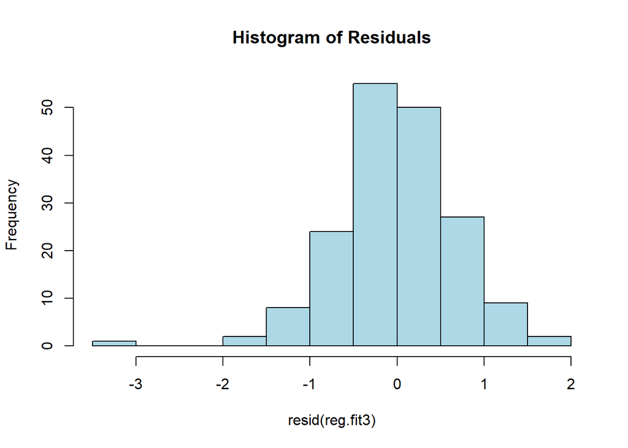

```r
hist(resid(reg.fit3), main = "Histogram of Residuals", col = "lightblue")
```

#### 10.1.2 Q-Q Plot of Model Residuals

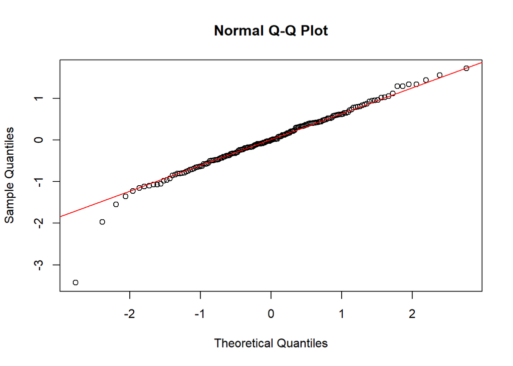

```r
qqnorm(resid(reg.fit3))
qqline(resid(reg.fit3), col = "red")
```

### 10.2 Lowest AIC Model

To evaluate the AIC in addition to MSE, I used `step()` which results in a Multiple Linear Regression with even more multicollinearity. `lm(formula = PRP ~ MbMIN + MMAX + CACH + CHMIN + CHMAX, data = reg.t)`

```r
step(reg.fit1)
```

```
## Start:  AIC=-127.59
## PRP ~ MYCT + MbMIN + MMAX + CACH + CHMIN + CHMAX
##
##         Df Sum of Sq    RSS      AIC
## - MYCT   1    0.0191 80.365 -129.547
## <none>               80.346 -127.589
## - CHMAX  1    2.8815 83.227 -123.317
## - CHMIN  1    3.2727 83.618 -122.482
## - MbMIN  1    5.2394 85.585 -118.344
## - CACH   1   17.8337 98.179  -93.908
## - MMAX   1   18.9407 99.287  -91.912
##
## Step:  AIC=-129.55
## PRP ~ MbMIN + MMAX + CACH + CHMIN + CHMAX
##
##         Df Sum of Sq    RSS      AIC
## <none>               80.365 -129.547
## - CHMAX  1    2.8822 83.247 -125.275
## - CHMIN  1    3.2852 83.650 -124.415
## - MbMIN  1    5.8511 86.216 -119.037
## - CACH   1   18.0989 98.464  -95.393
## - MMAX   1   19.1014 99.466  -93.590
```

```
##
## Call:
## lm(formula = PRP ~ MbMIN + MMAX + CACH + CHMIN + CHMAX, data = reg.t)
##
## Coefficients:
## (Intercept)        MbMIN         MMAX         CACH        CHMIN        CHMAX
##     -1.9698       0.1831       0.3684       0.1491       0.1654       0.1197
```

## 11. New Data Point:

```r
df.new.data <- data.frame(MYCT = 180,
                       MbMIN = 262,
                       MMAX = 4000,
                       CACH = 0.50, # avoid log_2 of 0 = -Inf
                       CHMIN = 1,
                       CHMAX = 3)
# transform
new.dl2 <- as.data.frame(lapply(df.new.data, log, base = 2))

# prediction/CI of transformed data.point
new.conf <- predict(reg.fit3,
                    newdata = new.dl2,
                    interval = 'confidence')
# undo transformation
new.conf2 <- sapply(new.conf, function(x){2^x})

# plugin method double check
plugin(new.dl2)
```

```
## [1] 3.999495
```

However this was the $y = \log_2{x}$ transformation; in order to get the same unit value as the original data frame and new data point a reverse transformation needs to take place using $x = 2^{y}$

### Prediction and Confidence Interval

The Model’s Output Prediction in *Transformed Value*:  
Mean Value : 4  
With 95% Confidence Internal that the average value of PRP will fall between : [3.77, 4.23]

Untransformed : 15.9944038, 13.6326443, 18.7653215

The Model’s Output Prediction with Confidence Interval in Comparable Units (coerce to integer) is:  
Mean Value : 15  
With 95% Confidence Internal that the average value of PRP will fall between : [13, 18]

## 12. Prediction Interval

```r
# prediction interval
new.pred <- predict(reg.fit3,
                    newdata = new.dl2,
                    interval = 'predict')
# undo transformation for correct value
new.pred2 <- sapply(new.pred, function(x){2^x})
```

### Prediction and Prediction Interval

The Model’s Prediction Interval in *Transformed Value* is:  
Mean Value : 4  
With 95% Prediction Internal that the actual value for PRP will fall between : [2.61, 5.39]  
Untransformed : 15.9944038, 6.1095058, 41.8726097

The Model’s Output Prediction with Prediction Interval in Comparable Units (coerce to integer) is:  
Mean Value : 15  
With 95% Prediction Internal that the actual value for PRP will fall between : [6, 41]

## Conclusion:

I used all features to start due to the Canvas Assignment instructions, but in real-world practice, I would not due to the high multicollinearity previously identified that subsequently got built into the final model by step-wise backward elimination and minimum AIC, so while these graphs and numbers look great; they indicate overfitting to the data set and would likely do poorly for other data. While the digital relationship of conversion is constant there are some questions on the low end value input accuracy and the amplified impact of some features on the target ‘PRP’.

[^1]: [kilobyte vs bit](https://thisvsthat.io/bit-vs-kilobyte)
[^2]: [Bit and Byte](https://thisvsthat.io/bit-vs-byte)
[^3]: [conversion calculator](https://thisvsthat.io/bit-vs-kilobyte)
[^4]: [CPU Wikipedia Page](https://en.wikipedia.org/wiki/Central_processing_unit)
[^5]: [computer performance Wikipedia Page](https://en.wikipedia.org/wiki/Computer_performance)
[^6]: [Channel capacity Wikipedia Page](https://en.wikipedia.org/wiki/Channel_capacity)
[^7]: [Bit and Byte](https://thisvsthat.io/bit-vs-byte)
[^8]: [Channel capacity Wikipedia Page](https://en.wikipedia.org/wiki/Channel_capacity)